# FinalProject

### Tutorial: Analysis of Top Streamers on Twitch

Jiahua Liu

#### Introduction

In the past few years, people have reduced the frequency of outdoor activities due to the spread of the epidemic. This phenomenon has given rise to the rapid growth of the live-streaming industry, with many people choosing to spend time watching live streams at home during the epidemic.

In this tutorial, we'll analyze the top 1000 Twitch streamer in 2021. This data is available on kaggle. According to the instructions, the data will be updated once a year, but the 2022 version has not been updated yet, so we will start with the 2021 data.

We will go over loading data, organizing data, analyzing data. We can also formulate some hypotheses from the data and prove them by statistical methods. We hope our analysis can provide some insights for other people who want to become Streamers.

[figure not shown]

## Data

#### Import Data

The library we are going to use is pandas, pandas is a package allow us to manipulate large dataset like excel Link to the dataset: https://www.kaggle.com/datasets/aayushmishra1512/twitchdata To make things easier, here's a mirror to this dataset: https://raw.githubusercontent.com/liujiahua123123/320Final/main/twitchdata-update.csv

`head` method provides with a general view of top 10 rows

```python
import pandas as pd

# read by url
data = pd.read_csv('https://raw.githubusercontent.com/liujiahua123123/320Final/main/twitchdata-update.csv')
data.head(10)
```

|  | Channel | Watch time(Minutes) | Stream time(minutes) | Peak viewers | Average viewers | Followers | Followers gained | Views gained | Partnered | Mature | Language |
| --- | --- | --- | --- | --- | --- | --- | --- | --- | --- | --- | --- |
| 0 | xQcOW | 6196161750 | 215250 | 222720 | 27716 | 3246298 | 1734810 | 93036735 | True | False | English |
| 1 | summit1g | 6091677300 | 211845 | 310998 | 25610 | 5310163 | 1370184 | 89705964 | True | False | English |
| 2 | Gaules | 5644590915 | 515280 | 387315 | 10976 | 1767635 | 1023779 | 102611607 | True | True | Portuguese |
| 3 | ESL_CSGO | 3970318140 | 517740 | 300575 | 7714 | 3944850 | 703986 | 106546942 | True | False | English |
| 4 | Tfue | 3671000070 | 123660 | 285644 | 29602 | 8938903 | 2068424 | 78998587 | True | False | English |
| 5 | Asmongold | 3668799075 | 82260 | 263720 | 42414 | 1563438 | 554201 | 61715781 | True | False | English |
| 6 | NICKMERCS | 3360675195 | 136275 | 115633 | 24181 | 4074287 | 1089824 | 46084211 | True | False | English |
| 7 | Fextralife | 3301867485 | 147885 | 68795 | 18985 | 508816 | 425468 | 670137548 | True | False | English |
| 8 | loltyler1 | 2928356940 | 122490 | 89387 | 22381 | 3530767 | 951730 | 51349926 | True | False | English |
| 9 | Anomaly | 2865429915 | 92880 | 125408 | 12377 | 2607076 | 1532689 | 36350662 | True | False | English |

Explanation of this dataset:

- Channel: The name of this streamer
- Watch time: Total time this streamer was watched
- Stream time: Total time this streamer streaming
- Peak viewers: The highest viewer at the same time this year
- Average viewers: The average time this streamer was watched
- Followers: number of followers
- Followers gained: number of followers gained this year
- Views gained: number of views gained this year
- Partnered: is this streamer works for Twitch.tv
- Mature: is this streamer age > 18
- Language: what language does this streamer speak

#### Clean Data

Let's check if there are missing values in the dataset (N/A). Checking for null values is an important part of data science. Most data analysis does not want nulls to be involved. According to the introduction of this dataset, all null/missing values use NA. So, we just need to check if there is NA in the dataframe

```python
data.isnull().sum()
```

```
Channel                 0
Watch time(Minutes)     0
Stream time(minutes)    0
Peak viewers            0
Average viewers         0
Followers               0
Followers gained        0
Views gained            0
Partnered               0
Mature                  0
Language                0
dtype: int64
```

Luckily, there's no missing values. We can use `shape` variable to get the size of this dataset

```python
data.shape
```

```
(1000, 11)
```

We have 1000 rows and 11 columns.

At this stage, we want to add some new columns, that would benefit our following analysis. Pinpointing to the fact that The earlier Streamer starts live-streaming, the more likely it is to accumulate more followers.

It is not fair to compare the number of followers across streamer, we should rather compare the percentage of growth in followers. We can use the following formula to do this

Growth = Followers Gained / ( Followers - Followers Gained )

Growth would be a float number, indicate the growth of followers for each streamer in terms of rate.

```python
# This is a batch operation, more like vector operation, it produced the exactly same result as you would do it element by element. But this approach is more efficiency
data['Growth'] = data['Followers gained'] / (data['Followers'] - data['Followers gained'])
data['Growth'].describe()
```

[output not shown]

Let us plot the distribution of this column. For plotting, we will use matplotlib library. matplotlib is a plotting library with low-level functionality.

```python
data = data[data['Growth'] < 5]
data.shape
```

```
(898, 12)
```

This will leave us with 898 streamers.

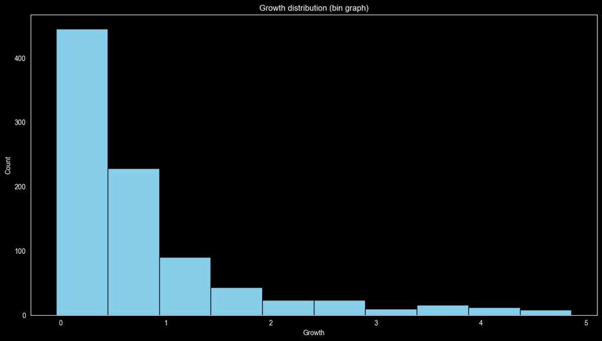

```python
import matplotlib.pyplot as plt
import seaborn as sns

fig, ax = plt.subplots(figsize=(15, 8))

ax.hist(data['Growth'], ec="black", color="skyblue", bins=10)
ax.set_ylabel('Count')
ax.grid(False)
ax.set_xlabel('Growth')
ax.set_title('Growth distribution (bin graph)', loc='center');
```

This distribution has a long tail. Major streamers has growth in 0 - 1. Only small numbers of streamers are able to reach a growth more than 1. Reaching a growth of more than 1 means His/Her follower doubled in one year.

There's also a category column, which is 'language'. Let's check out its distribution with the similar approach. We can also investigate the distribution of 'Mature' and 'Patterned'

[More about Distribution](https://en.wikipedia.org/wiki/Distribution)

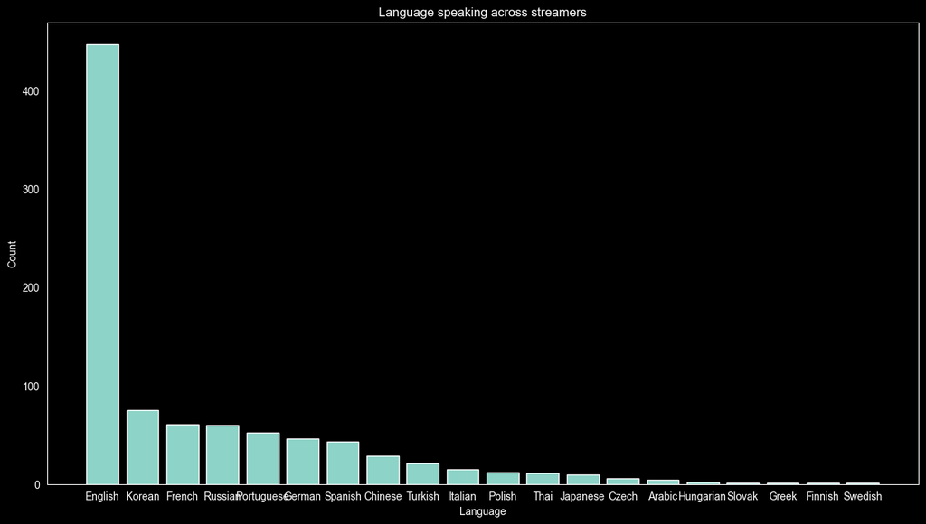

```python
fig1, ax = plt.subplots(figsize=(15, 8))

# we count how many times a language appear
language_accum = data['Language'].value_counts()
# create a bar based on this
ax.bar(language_accum.index, language_accum)
ax.set_xlabel('Language')
ax.set_ylabel('Count')
ax.grid(False)
ax.set_title('Language speaking across streamers', loc='center');
```

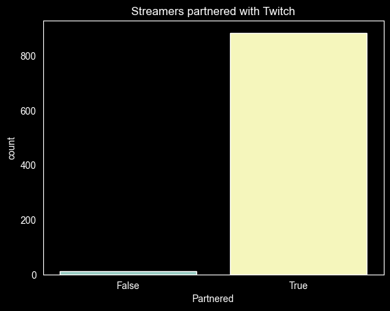

```python
sns.countplot(x='Partnered', data=data).set(title='Streamers partnered with Twitch');
```

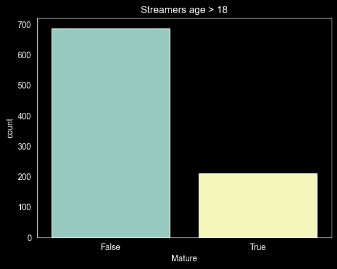

```python
sns.countplot(x='Mature', data=data).set(title='Streamers age > 18');
```

In the language part, the majority of streamer speaks english. This is probably because the market of Twitch is in U.S. However, it's quite surprising that nearly 700 streamers in the top 1000 streamers are not mature.

Distribution of numeral columns are curial for understanding the dataset.

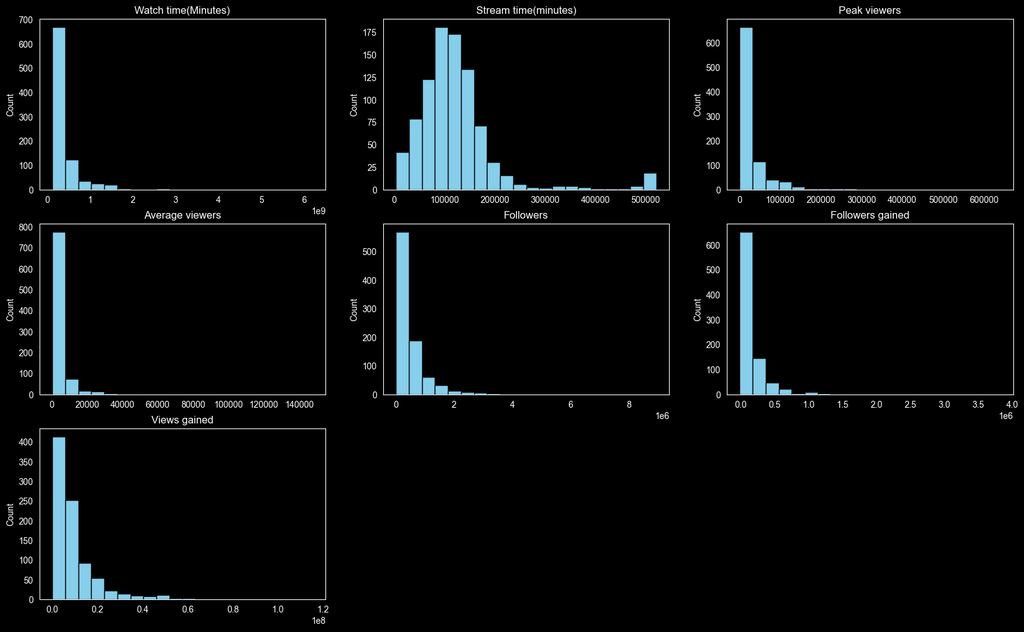

```python
# all the numeral column
num_columns = ['Watch time(Minutes)', 'Stream time(minutes)', 'Peak viewers', 'Average viewers', 'Followers',
               'Followers gained', 'Views gained']


fig2 = plt.figure(figsize=(20, 12))
grid = fig2.add_gridspec(3, 3)

count = 0
subplot_list = []
# assign the graph row by row
for i in range(0, len(num_columns)):
    subplot_list.append(fig2.add_subplot(grid[int(i / 3), i % 3]))

for col, subplot in zip(num_columns, subplot_list):
    subplot.hist(data[col], bins=20, ec="black", color="skyblue")
    subplot.set_title(col)
    subplot.set_ylabel('Count')
    subplot.grid(False)
```

Interpretation

- All the numerical columns except for Stream time is heavily right skewed.
- Stream time seems to have a normal distribution, with little right skewed.

## Data Exploration and Analysis

We already have a general understanding of this data, next we need to explore the value of the data to obtain more useful information.

Data exploration and analysis is defined as the process of examining a dataset in order to gain insights and better understand its characteristics. This typically involves using various techniques and tools to explore the data, such as visualizing the data using graphs and charts, summarizing the data using descriptive statistics, and looking for patterns and trends in the data. The goal of data exploration and analysis is to discover useful information that can help inform decision-making and guide further research or investigation.

#### Heat Map

Heatmap can be used to visualize the correlation between different variables in a dataset, or to identify areas where certain events or activities are concentrated.

[More about Heat Map](https://en.wikipedia.org/wiki/Heat_map)

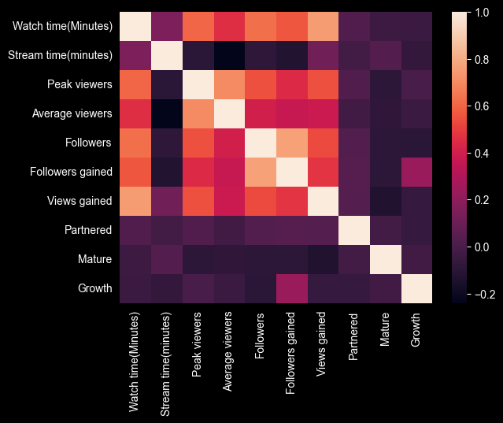

```python
sns.heatmap(data.corr());
```

Let's investigate further first on Watch time and Views gained. We plot watch time vs views gained

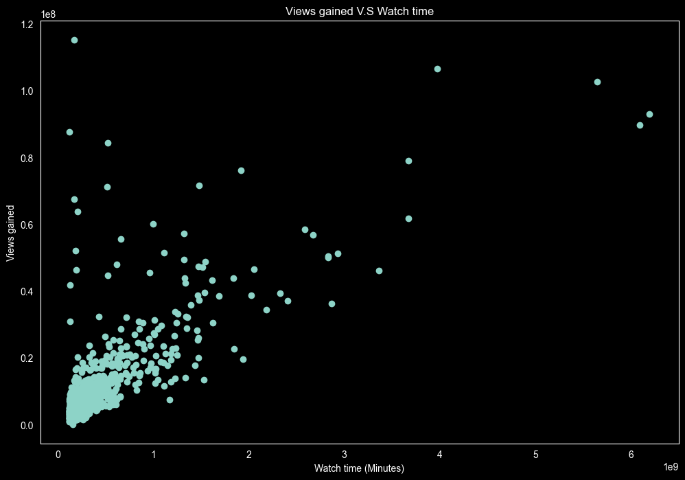

```python
fig3, ax = plt.subplots(1, 1, figsize=(12, 8))
ax.scatter(x=data['Watch time(Minutes)'], y=data['Views gained'])
ax.set_xlabel('Watch time (Minutes)')
ax.set_ylabel('Views gained')
ax.set_title('Views gained V.S Watch time', loc='center')
```

Quite obvious that the two variables are linearly related. In statistics, a linear relationship is a relationship between two variables that can be represented by a straight line. This means that if one variable increases or decreases, the other variable also increases or decreases at a constant rate.

However, that's not enough, let's see if other factor plays a role in this relation. For example, look into language. Since English is taking the majority. We can consider all other languages as Non-English.

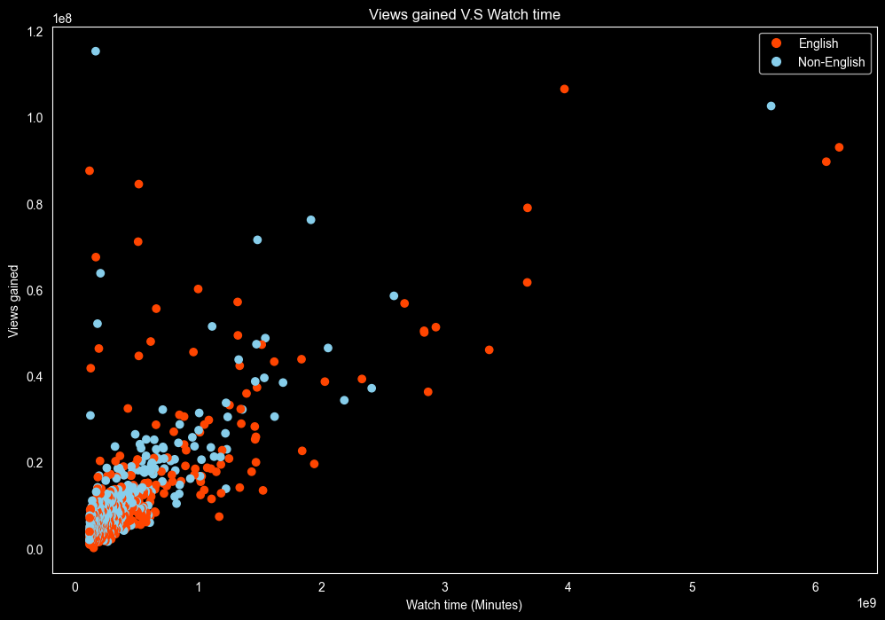

```python
# Define a function to map language values to colors
def language_to_color(l):
    if l == 'English':
        return "orangered"
    return "skyblue"

# Set up figure and axes for scatter plot
fig4, ax = plt.subplots(1, 1, figsize=(12, 8))
ax.scatter(x=data['Watch time(Minutes)'], y=data['Views gained'], c=data['Language'].apply(language_to_color))
ax.set_xlabel('Watch time (Minutes)')
ax.set_ylabel('Views gained')
ax.set_title('Views gained V.S Watch time', loc='center')

# add marker.
import matplotlib.lines as mlines
english_mark = mlines.Line2D([], [], color='orangered', marker='o', linestyle='None',
                             markersize=7, label='English')
non_english_mark = mlines.Line2D([], [], color='skyblue', marker='o', linestyle='None',
                                 markersize=7, label='Non-English')
ax.legend(handles=[english_mark, non_english_mark]);
```

This isn't clear enough, we can add a line of best fit, to see if there's a difference.

We use sklearn to do this. Sklearn is a machine learning library for the Python programming language. It is designed to provide a simple and efficient way to integrate machine learning into applications, and contains a wide range of algorithms for classification, regression, clustering, and other common tasks in machine learning. Linear Regression is one of the most basic.

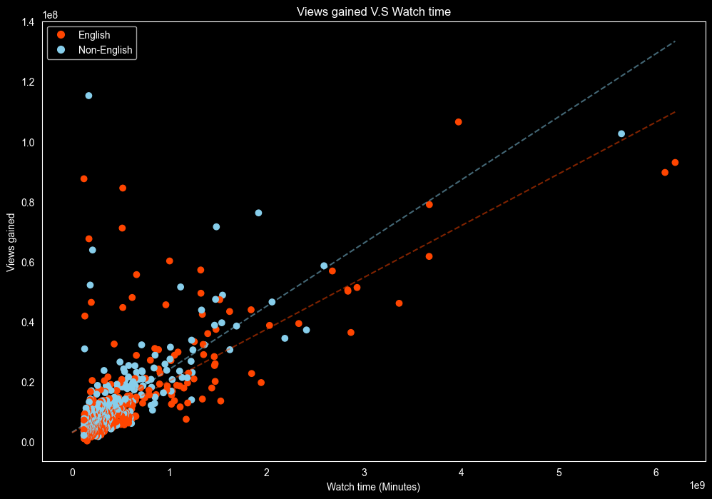

```python
# Define a function to map language values to colors
def language_to_color(l):
    if l == 'English':
        return "orangered"
    return "skyblue"

# Make a copy of the data to avoid modifying the original data
data_copied_0 = data.copy()

# Add a new column 'isEnglish' that is True if the 'Language' column is 'English' and False otherwise
data_copied_0['isEnglish'] = data_copied_0['Language'] == 'English'

# Get the maximum value in the 'Watch time(Minutes)' column to use as the x-axis limit
x_max = max(data['Watch time(Minutes)'])

# Set up figure and axes for scatter plot
fig5, ax = plt.subplots(1, 1, figsize=(12, 8))

# Create scatter plot with 'Watch time(Minutes)' on x-axis and 'Views gained' on y-axis,
# and color each point based on the 'Language' column
ax.scatter(x=data_copied_0['Watch time(Minutes)'], y=data_copied_0['Views gained'],
           c=data_copied_0['Language'].apply(language_to_color))

# Set labels and title for the plot
ax.set_xlabel('Watch time (Minutes)')
ax.set_ylabel('Views gained')
ax.set_title('Views gained V.S Watch time', loc='center')

# Create legend for the scatter plot
import matplotlib.lines as mlines
english_mark = mlines.Line2D([], [], color='orangered', marker='o', linestyle='None',
                             markersize=7, label='English')
non_english_mark = mlines.Line2D([], [], color='skyblue', marker='o', linestyle='None',
                                 markersize=7, label='Non-English')
ax.legend(handles=[english_mark, non_english_mark])


from sklearn.linear_model import LinearRegression
# create regression line for each group, we group it by if that's english
for c, dl in data_copied_0.groupby(['isEnglish']):
    import numpy as np
    # reshape,
    # we need to have array of feature array.
    X = np.array(dl['Watch time(Minutes)']).reshape(-1, 1)
    Y = dl['Views gained']
    # create regression line
    reg = LinearRegression().fit(X, Y)
    # pretty print the model
    sign = "+" if reg.intercept_ > 0 else "-"
    ax.add_line(mlines.Line2D(alpha=0.5, ls='--', xdata=[0, x_max], ydata=[reg.predict([[0]]), reg.predict([[x_max]])],
                              c="orangered" if c else "skyblue"))
```

In a linear regression model, the dependent variable is predicted from the independent variable using a linear equation. This equation takes the form Y = a + bX, where X is the independent variable, Y is the dependent variable, 'a' is the intercept, and 'b' is the slope of the line. Linear regression is used to analyze the relationship between two variables and to make predictions about the dependent variable based on the value of the independent variable.

As can be seen from the figure, the slopes of the two regression lines are not the same. Means they have different 'b'. This suggests that language speaking plays a role in affecting views gained. For the same amount of watch time, streamer who speak non-english get a higher views than those speak english. Frankly speaking, this is counter-intuitive, because people who watch Twitter mainly speaks English.

Next, we use similar approach to check if Mature and Partner plays a role in this relationship.

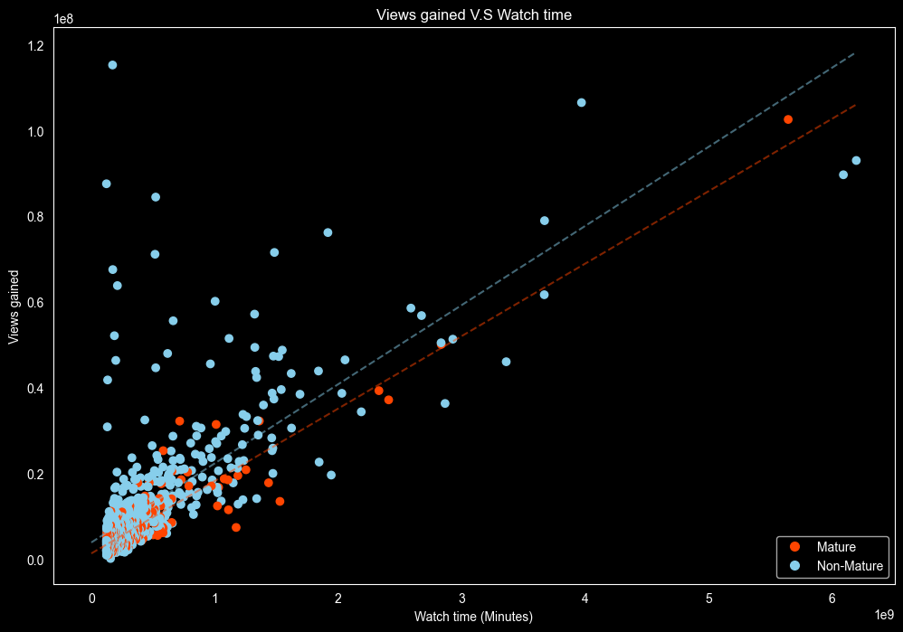

```python
# Define a function to map boolean values to colors
def bool_to_color(b):
    return 'orangered' if b else 'skyblue'

# Set up figure and axes for scatter plot
fig5, ax = plt.subplots(1, 1, figsize=(12, 8))

# Create scatter plot with 'Watch time(Minutes)' on x-axis and 'Views gained' on y-axis,
# and color each point based on the 'Mature' column
ax.scatter(x=data_copied_0['Watch time(Minutes)'], y=data_copied_0['Views gained'],
           c=data_copied_0['Mature'].apply(bool_to_color))

# Set labels and title for the plot
ax.set_xlabel('Watch time (Minutes)')
ax.set_ylabel('Views gained')
ax.set_title('Views gained V.S Watch time', loc='center')

# Create legend for the scatter plot
import matplotlib.lines as mlines
mark0 = mlines.Line2D([], [], color='orangered', marker='o', linestyle='None',
                      markersize=7, label='Mature')
mark1 = mlines.Line2D([], [], color='skyblue', marker='o', linestyle='None',
                      markersize=7, label='Non-Mature')
ax.legend(handles=[mark0, mark1])

# Import LinearRegression model from scikit-learn
from sklearn.linear_model import LinearRegression

# Iterate over groups of data, grouped by 'Mature' column
for c, dl in data_copied_0.groupby(['Mature']):
    # Convert 'Watch time(Minutes)' column to a numpy array and reshape it to a 2D array
    X = np.array(dl['Watch time(Minutes)']).reshape(-1, 1)
    # Set 'Views gained' column as the response variable
    Y = dl['Views gained']
    # Create a linear regression model
    reg = LinearRegression().fit(X, Y)
    # Add the regression line to the plot with a dashed style and the color mapped to the 'Mature' value
    ax.add_line(mlines.Line2D(alpha=0.5, ls='--',  xdata=[0, x_max], ydata=[reg.predict([[0]]), reg.predict([[x_max]])],
                              c=bool_to_color(c)))
```

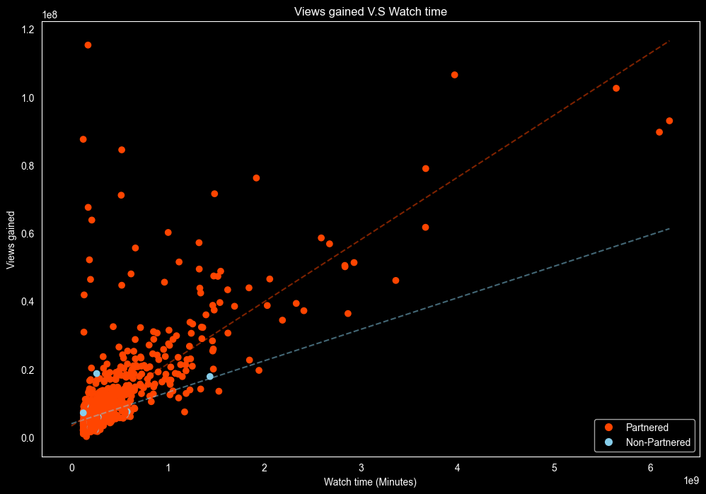

```python
# Set up figure and axes for scatter plot
fig5, ax = plt.subplots(1, 1, figsize=(12, 8))

# Create scatter plot with 'Watch time(Minutes)' on x-axis and 'Views gained' on y-axis,
# and color each point based on the 'Partnered' column
ax.scatter(x=data_copied_0['Watch time(Minutes)'], y=data_copied_0['Views gained'],
           c=data_copied_0['Partnered'].apply(bool_to_color))

# Set labels and title for the plot
ax.set_xlabel('Watch time (Minutes)')
ax.set_ylabel('Views gained')
ax.set_title('Views gained V.S Watch time', loc='center')

# Create legend for the scatter plot
import matplotlib.lines as mlines
mark0 = mlines.Line2D([], [], color='orangered', marker='o', linestyle='None',
                      markersize=7, label='Partnered')
mark1 = mlines.Line2D([], [], color='skyblue', marker='o', linestyle='None',
                      markersize=7, label='Non-Partnered')
ax.legend(handles=[mark0, mark1])

# Import LinearRegression model from scikit-learn
from sklearn.linear_model import LinearRegression

# Iterate over groups of data, grouped by 'Partnered' column
for c, dl in data_copied_0.groupby(['Partnered']):
    # Convert 'Watch time(Minutes)' column to a numpy array and reshape it to a 2D array
    X = np.array(dl['Watch time(Minutes)']).reshape(-1, 1)
    # Set 'Views gained' column as the response variable
    Y = dl['Views gained']
    # Create a linear regression model
    reg = LinearRegression().fit(X, Y)
    # Add the regression line to the plot with a dashed style and the color mapped to the 'Partnered' value
    ax.add_line(mlines.Line2D(alpha=0.5, ls='--', xdata=[0, x_max], ydata=[reg.predict([[0]]), reg.predict([[x_max]])],
                              c=bool_to_color(c)))
```

The first graph indicates that being an adult is also one of the factors that affects View Gained. For two Streamers with the same Watch time, the minor one may have more Views.

The second graph wasn't so meaningful because the input is highly unbalanced. By this, it means that there are too many samples being partnered, but too less for non-partnered, the regression line for non-partnered is not that reliable.

For other co-relations, we can explore the relationships present in the data in the same way. Due to space issues, we are not showing other similar explorations

We next prove in a more mathematical way that these relations hold.

## Hypothesis testing

Hypothesis testing is a statistical method used to determine whether there is sufficient evidence in a sample of data to infer a certain property of a population.

Hypothesis testing is done by defining a null hypothesis, which represents the default assumption that there is no relationship between the variables being studied, and an alternative hypothesis, which represents the claim that there is a relationship between the variables.

Normally, null hypothesis represent the hypothesis that nothing happens. For example, there's no relationship between views gained and watch time. Alternative hypothesis represent the hypothesis that we wish to prove exists. We can not say we 'accept' the alternative hypothesis, but say we 'reject' the null hypothesis.

[More about Hypothesis Testing](https://en.wikipedia.org/wiki/Statistical_hypothesis_testing)

The package we will be using is `statmodel`.

The `statsmodels` package is a python module that provides classes and functions for the estimation of many different statistical models, as well as for conducting statistical tests, and statistical data exploration.

The first hypothesis test we will do is linear regression analysis. This type of test involves fitting a linear regression model to the data and evaluating its statistical significance. Our null hypothesis is that views and watch time has no relation. The alternative hypothesis is that there's a linear relationship between views and watch time.

```python
import statsmodels.formula.api as smf

# Make a copy of the data and rename the columns for use with statsmodels
data_copied_for_smf = data.copy()
data_copied_for_smf['Y'] = data_copied_for_smf['Views gained']
data_copied_for_smf['X'] = data_copied_for_smf['Watch time(Minutes)']
# Fit a linear regression model using the OLS method from statsmodels
res1 = smf.ols(formula='Y ~ X', data=data_copied_for_smf).fit()
res1.summary()
```

OLS Regression Results

| Dep. Variable: | Y | R-squared: | 0.565 |
| --- | --- | --- | --- |
| Model: | OLS | Adj. R-squared: | 0.565 |
| Method: | Least Squares | F-statistic: | 1164. |
| Date: | Fri, 16 Dec 2022 | Prob (F-statistic): | 3.90e-164 |
| Time: | 11:18:54 | Log-Likelihood: | -15641. |
| No. Observations: | 898 | AIC: | 3.129e+04 |
| Df Residuals: | 896 | BIC: | 3.130e+04 |
| Df Model: | 1 |  |  |
| Covariance Type: | nonrobust |  |  |

|  | coef | std err | t | P>\|t\| | [0.025 | 0.975] |
| --- | --- | --- | --- | --- | --- | --- |
| Intercept | 3.275e+06 | 3.72e+05 | 8.808 | 0.000 | 2.55e+06 | 4.01e+06 |
| X | 0.0182 | 0.001 | 34.114 | 0.000 | 0.017 | 0.019 |

| Omnibus: | 1012.880 | Durbin-Watson: | 1.859 |
| --- | --- | --- | --- |
| Prob(Omnibus): | 0.000 | Jarque-Bera (JB): | 84653.982 |
| Skew: | 5.482 | Prob(JB): | 0.00 |
| Kurtosis: | 49.284 | Cond. No. | 8.72e+08 |

Notes:  
[1] Standard Errors assume that the covariance matrix of the errors is correctly specified.  
[2] The condition number is large, 8.72e+08. This might indicate that there are  
strong multicollinearity or other numerical problems.

A p-value is a statistical measure that indicates the likelihood that a given result could have occurred by chance. In other words, a p-value is a way of quantifying the significance of a result. If a p-value is low, it means that the result is unlikely to have occurred by chance and is therefore more likely to be significant. On the other hand, if the p-value is high, it means that the result is likely to have occurred by chance and is therefore not statistically significant. In general, a p-value of 0.05 or less is considered to be statistically significant.

If the result is considered to be statistically significant, we can reject our null hypothesis. In this case, our p-value is 0.000. We can safely reject our null hypothesis and accept the alternative. Which is there's a linear relationship between Views gained and Watch time.

However, we do note that the R-squared value wasn't satisfying.

R-squared is an indicator that always between 0 and 1, where 0 indicates that the model does not explain any of the variance in the dependent variable, and 1 indicates that the model explains all variance in the dependent variable. A higher R-squared value indicates a better-fitting model. One possible Explanation is that other factors plays a role in this relation also.

[More about P Value](https://www.investopedia.com/terms/p/p-value.asp#:~:text=A%20p%2Dvalue%20is%20a,significance%20of%20the%20observed%20difference.)

```python
import scipy.stats
data_for_sci = data.copy()

# we get the slope
data_for_sci['slope'] = data['Views gained']  / data['Watch time(Minutes)']
# group
data_english_speaking = data_for_sci[data_for_sci['Language'] == 'English']
data_non_english_speaking = data_for_sci[data_for_sci['Language'] != 'English']
# run paired t test
t, p = scipy.stats.ttest_ind(data_english_speaking['slope'], data_non_english_speaking['slope'])
p
```

```
0.04274906069094583
```

We got a p-value of 0.04, smaller than 0.05. We will reject our null hypothesis and accept the alternative. Which in this case is: speaking english or not will affect views gained per watch time.

## Prediction

We can get a lot of information after these analyses. This information can be used to make some meaningful applications. For example, we would like to do a predictor based on the facts we found above. The predictor can predict the views gained for some streamer given the watch time, language speaking and mature or not.

[More about Interation term](https://stattrek.com/multiple-regression/interaction#:~:text=In%20regression%2C%20an%20interaction%20effect,or%20more%20other%20independent%20variables.)

```python
data_copied_for_smf = data.copy()
data_copied_for_smf['Y'] = data_copied_for_smf['Views gained']
data_copied_for_smf['X'] = data_copied_for_smf['Watch time(Minutes)']
# Note that : is the interation term
res1 = smf.ols(formula='Y ~ X + Language + Mature + X:Language:Mature', data=data_copied_for_smf).fit()
res1.summary()
```

OLS Regression Results

| Dep. Variable: | Y | R-squared: | 0.610 |
| --- | --- | --- | --- |
| Model: | OLS | Adj. R-squared: | 0.587 |
| Method: | Least Squares | F-statistic: | 27.03 |
| Date: | Fri, 16 Dec 2022 | Prob (F-statistic): | 4.46e-140 |
| Time: | 10:57:08 | Log-Likelihood: | -15593. |
| No. Observations: | 898 | AIC: | 3.129e+04 |
| Df Residuals: | 848 | BIC: | 3.153e+04 |
| Df Model: | 49 |  |  |
| Covariance Type: | nonrobust |  |  |

|  | coef | std err | t | P>\|t\| | [0.025 | 0.975] |
| --- | --- | --- | --- | --- | --- | --- |
| Intercept | 5.822e+05 | 1.32e+07 | 0.044 | 0.965 | -2.54e+07 | 2.65e+07 |
| Language[T.Chinese] | 1.961e+06 | 1.36e+07 | 0.144 | 0.885 | -2.48e+07 | 2.87e+07 |
| Language[T.Czech] | 3.713e+06 | 1.54e+07 | 0.241 | 0.809 | -2.65e+07 | 3.39e+07 |
| Language[T.English] | 3.424e+06 | 1.32e+07 | 0.259 | 0.796 | -2.26e+07 | 2.94e+07 |
| Language[T.Finnish] | -0.5363 | 2.452 | -0.219 | 0.827 | -5.348 | 4.276 |
| Language[T.French] | -3.604e+05 | 1.33e+07 | -0.027 | 0.978 | -2.65e+07 | 2.58e+07 |
| Language[T.German] | 2.372e+06 | 1.34e+07 | 0.178 | 0.859 | -2.38e+07 | 2.86e+07 |
| Language[T.Greek] | 1.9349 | 8.780 | 0.220 | 0.826 | -15.298 | 19.168 |
| Language[T.Hungarian] | -0.8021 | 3.148 | -0.255 | 0.799 | -6.981 | 5.376 |
| Language[T.Italian] | 9.387e+06 | 1.38e+07 | 0.679 | 0.497 | -1.78e+07 | 3.65e+07 |
| Language[T.Japanese] | -383.3812 | 1.39e+07 | -2.76e-05 | 1.000 | -2.73e+07 | 2.73e+07 |
| Language[T.Korean] | 3.603e+05 | 1.33e+07 | 0.027 | 0.978 | -2.57e+07 | 2.65e+07 |
| Language[T.Polish] | 5.992e+05 | 1.43e+07 | 0.042 | 0.967 | -2.75e+07 | 2.87e+07 |
| Language[T.Portuguese] | 2.17e+06 | 1.33e+07 | 0.163 | 0.871 | -2.4e+07 | 2.83e+07 |
| Language[T.Russian] | 7.284e+06 | 1.33e+07 | 0.546 | 0.585 | -1.89e+07 | 3.35e+07 |
| Language[T.Slovak] | 2.3893 | 12.461 | 0.192 | 0.848 | -22.069 | 26.848 |
| Language[T.Spanish] | 8.033e+05 | 1.34e+07 | 0.060 | 0.952 | -2.54e+07 | 2.7e+07 |
| Language[T.Swedish] | -0.8768 | 5.420 | -0.162 | 0.872 | -11.515 | 9.762 |
| Language[T.Thai] | 3.129e+06 | 1.45e+07 | 0.216 | 0.829 | -2.53e+07 | 3.16e+07 |
| Language[T.Turkish] | 2.175e+06 | 1.37e+07 | 0.159 | 0.874 | -2.47e+07 | 2.91e+07 |
| Mature[T.True] | -2.689e+06 | 1e+06 | -2.687 | 0.007 | -4.65e+06 | -7.25e+05 |
| X | 0.0096 | 0.047 | 0.203 | 0.840 | -0.083 | 0.103 |
| X:Mature[T.True] | 10.3701 | 27.754 | 0.374 | 0.709 | -44.105 | 64.845 |
| X:Language[T.Chinese]:Mature[False] | 0.0158 | 0.048 | 0.328 | 0.743 | -0.079 | 0.111 |
| X:Language[T.Czech]:Mature[False] | 0.0099 | 0.064 | 0.155 | 0.877 | -0.115 | 0.135 |
| X:Language[T.English]:Mature[False] | 0.0078 | 0.047 | 0.164 | 0.869 | -0.085 | 0.101 |
| X:Language[T.Finnish]:Mature[False] | -0.3742 | 2.046 | -0.183 | 0.855 | -4.391 | 3.643 |
| X:Language[T.French]:Mature[False] | 0.0183 | 0.047 | 0.385 | 0.700 | -0.075 | 0.111 |
| X:Language[T.German]:Mature[False] | 0.0064 | 0.048 | 0.134 | 0.893 | -0.087 | 0.100 |
| X:Language[T.Greek]:Mature[False] | 0.0059 | 0.043 | 0.138 | 0.890 | -0.078 | 0.089 |
| X:Language[T.Hungarian]:Mature[False] | 0.0150 | 0.038 | 0.400 | 0.689 | -0.059 | 0.089 |
| X:Language[T.Italian]:Mature[False] | -0.0028 | 0.049 | -0.057 | 0.954 | -0.099 | 0.094 |
| X:Language[T.Japanese]:Mature[False] | 0.0098 | 0.048 | 0.205 | 0.838 | -0.084 | 0.104 |
| X:Language[T.Korean]:Mature[False] | 0.0142 | 0.047 | 0.299 | 0.765 | -0.079 | 0.107 |
| X:Language[T.Polish]:Mature[False] | 0.0168 | 0.049 | 0.341 | 0.733 | -0.080 | 0.113 |
| X:Language[T.Portuguese]:Mature[False] | 0.0123 | 0.047 | 0.259 | 0.796 | -0.081 | 0.105 |
| X:Language[T.Russian]:Mature[False] | 0.0118 | 0.048 | 0.249 | 0.804 | -0.081 | 0.105 |
| X:Language[T.Slovak]:Mature[False] | 0.0167 | 0.032 | 0.515 | 0.606 | -0.047 | 0.080 |
| X:Language[T.Spanish]:Mature[False] | 0.0144 | 0.047 | 0.304 | 0.761 | -0.079 | 0.108 |
| X:Language[T.Swedish]:Mature[False] | 1.574e-08 | 9.41e-08 | 0.167 | 0.867 | -1.69e-07 | 2e-07 |
| X:Language[T.Thai]:Mature[False] | 0.0081 | 0.052 | 0.155 | 0.877 | -0.094 | 0.110 |
| X:Language[T.Turkish]:Mature[False] | 0.0190 | 0.049 | 0.391 | 0.696 | -0.077 | 0.115 |
| X:Language[T.Chinese]:Mature[True] | -10.3498 | 27.798 | -0.372 | 0.710 | -64.911 | 44.212 |
| X:Language[T.Czech]:Mature[True] | -10.3557 | 27.797 | -0.373 | 0.710 | -64.914 | 44.203 |
| X:Language[T.English]:Mature[True] | -10.3657 | 27.798 | -0.373 | 0.709 | -64.927 | 44.196 |
| X:Language[T.Finnish]:Mature[True] | -10.3223 | 27.738 | -0.372 | 0.710 | -64.765 | 44.121 |
| X:Language[T.French]:Mature[True] | -10.3498 | 27.798 | -0.372 | 0.710 | -64.911 | 44.212 |
| X:Language[T.German]:Mature[True] | -10.3638 | 27.798 | -0.373 | 0.709 | -64.925 | 44.198 |
| X:Language[T.Greek]:Mature[True] | 7.009e-10 | 1.43e-09 | 0.489 | 0.625 | -2.11e-09 | 3.51e-09 |
| X:Language[T.Hungarian]:Mature[True] | -10.3234 | 27.735 | -0.372 | 0.710 | -64.761 | 44.114 |
| X:Language[T.Italian]:Mature[True] | -10.3805 | 27.800 | -0.373 | 0.709 | -64.945 | 44.184 |
| X:Language[T.Japanese]:Mature[True] | 0 | 0 | nan | nan | 0 | 0 |
| X:Language[T.Korean]:Mature[True] | -10.3507 | 27.798 | -0.372 | 0.710 | -64.912 | 44.211 |
| X:Language[T.Polish]:Mature[True] | -10.3457 | 27.799 | -0.372 | 0.710 | -64.908 | 44.216 |
| X:Language[T.Portuguese]:Mature[True] | -10.3614 | 27.798 | -0.373 | 0.709 | -64.923 | 44.200 |
| X:Language[T.Russian]:Mature[True] | -10.3534 | 27.798 | -0.372 | 0.710 | -64.915 | 44.208 |
| X:Language[T.Slovak]:Mature[True] | 0 | 0 | nan | nan | 0 | 0 |
| X:Language[T.Spanish]:Mature[True] | -10.3409 | 27.798 | -0.372 | 0.710 | -64.902 | 44.220 |
| X:Language[T.Swedish]:Mature[True] | -10.3197 | 27.699 | -0.373 | 0.710 | -64.687 | 44.048 |
| X:Language[T.Thai]:Mature[True] | -10.3388 | 27.798 | -0.372 | 0.710 | -64.900 | 44.223 |
| X:Language[T.Turkish]:Mature[True] | -10.3416 | 27.798 | -0.372 | 0.710 | -64.903 | 44.220 |

| Omnibus: | 1043.974 | Durbin-Watson: | 1.916 |
| --- | --- | --- | --- |
| Prob(Omnibus): | 0.000 | Jarque-Bera (JB): | 98622.308 |
| Skew: | 5.734 | Prob(JB): | 0.00 |
| Kurtosis: | 53.043 | Cond. No. | 1.24e+16 |

Notes:  
[1] Standard Errors assume that the covariance matrix of the errors is correctly specified.  
[2] The smallest eigenvalue is 4.06e-12. This might indicate that there are  
strong multicollinearity problems or that the design matrix is singular.

## Conclusion

However, our analysis needs to be completed. There is much more value to be mined from the data. We have only studied the relationship between Watched time and Views gained; however, as Streamers, we have the most control over Stream time. Therefore, analyzing the relationship between Stream time and Watched time or Views gained is worthwhile. Second, in the beginning, we showed how to calculate Growth, but we could not use it in the subsequent analysis.

After thoroughly analyzing the data, we have reached the following conclusions:

- We have successfully identified the key trends and patterns in the data, which provide valuable insights into the subject of our study.
- Our findings confirm several hypotheses that we had formulated at the beginning of the project.
- We have developed a predictive models that can be used to forecast future outcomes based on the data.
- We also pointed out where area need to be work further.

Overall, this process has demonstrated adequate amounts of data science skills. I hope This tutorial can lead you to analyze data as well.